# Exploratory Analysis

## Project title

Exploring the Users’ Experience on Netflix.com

### Authors

Ronnie Chen: rchen24@uw.edu Eric Kuo: ekuo0210@uw.edu Gia An Nguyen: giaan01@uw.edu Angela Li: angli03@uw.edu Leo Ren:2319277580@qq.com &mengqr12@uw.edu

### Date

February 21, Winter 2022

### Abstract

We are concerned about how Netflix’s suggestion engine will allow the consumers to have a more viewer friendly experience, due to the rising popularity of this streaming platform today. To address this concern, we plan to analyze user rating size in relation to rating to explore the influence of Rating level on user rating score based on Netflix’s search engines.

### Keywords

Algorithms, suggestion engines, Netflix, streaming platform

### Introduction

In this project we decided to use a Kaggle dataset display Netflix shows and their ratings. Since the dataset incorporates Netflix’s suggestion engine into the aggregated data, our group was thinking about exploring research questions relating to its impact and extension. As such we’d like to explore how Netflix’s suggestion engine allow the consumers to have a more viewer friendly experience? How does their suggestion engine impact a show’s ratings and vice versa of how does show’s ratings impact Netflix’s suggestion engine? Does release year have an impact on the suggestion engine? Do ratings make an impact on when Netflix decides to stop hosting a show? The possibilities with this dataset are numerous. We chose this dataset because we wanted to work with a topic that was entertaining and interesting but still prompting. I think that since we all have our personal experiences with Netflix, when working with this data, we are more invested into our research and finding out the results since they have a direct relation to us as part of Netflix’s userbase. Furthermore, the impact of our findings is substantial considering the scope of Netflix’s impact. Especially during the pandemic, their userbase has grown significantly when people searched for entertainment options during lockdown. Since it also provides convenience from the comfort of your own home, I believe that any of our findings can make a substantial impact.

### Related Work

The possibilities of streaming has shifted our world through genres, labels and categories our daily media consumption. Netflix uses machine learning and algorithms to break down its viewer’s recommended shows and predicts other shows to keep their consumers interested. Take the trending Korean drama, Squid Game, for example, how did this show become so popular on this streaming platform? While the Korean show has its personal labeled genre, it also contains “hyper-specific categories” that are stored into “meta-data - the behind-the-scenes codes that support platforms like Spotify” (Beer). According to the Wired article, they gather “what people watch, what they watch after, what they watch before, what they watched a year ago, what they’ve watched recently, and what time of day” and Netflix combine this information “with more data aimed at understanding the content of the shows.” This information from their viewers then gets categorized and analyzed into multiple taste groups that are used for machine learning algorithms. This method is implemented all across the word. A research study conducted by Gomez-Uribe and Neil Hunt indicated there is a collection of recommender algorithm that Netflix uses such as the personalized video ranker (PVR) and Top N video ranker algorithm that catalogs videos for each member profile on the homepage of Netflix, or the video-video similarity algorithm for Netflix’s Because You Watched (BYW) recommendations. There are numerous algorithms implemented with Netflix’s suggestion engines and with this project, we will dive into how exactly this huge streaming platform recommends similar shows through its User Rating Score, Rating Description, Release Year, Title, and more complete the user’s Netflix experience.

### Limitations & Challenges

While doing research, we might run into challenges with misinformation and biased resources. Because Netflix has millions of subscribers that watch a variety of shows, it would be challenging for us to analyze how interactions with Netflix can alter the preferences. Moreover, the designated factors such as rating that could impact the interests limit our ability to better understand what is the main influencer to these recommendations. There are also data limitations in which the data can not represent all subscribers, this will create bias in our findings. The time of a day, devices, and duration are some of the existing data to be used as inputs for Netflix to process in their algorithms, but duration might not be accurate especially if one kept playing shows without watching. We need to address more broadly the accuracy of data and view it more holistically.

### Table

[output not shown]

[output cut: 8778 more lines]

### Chart 1

What are the top 10 directors with the largest number of movies?

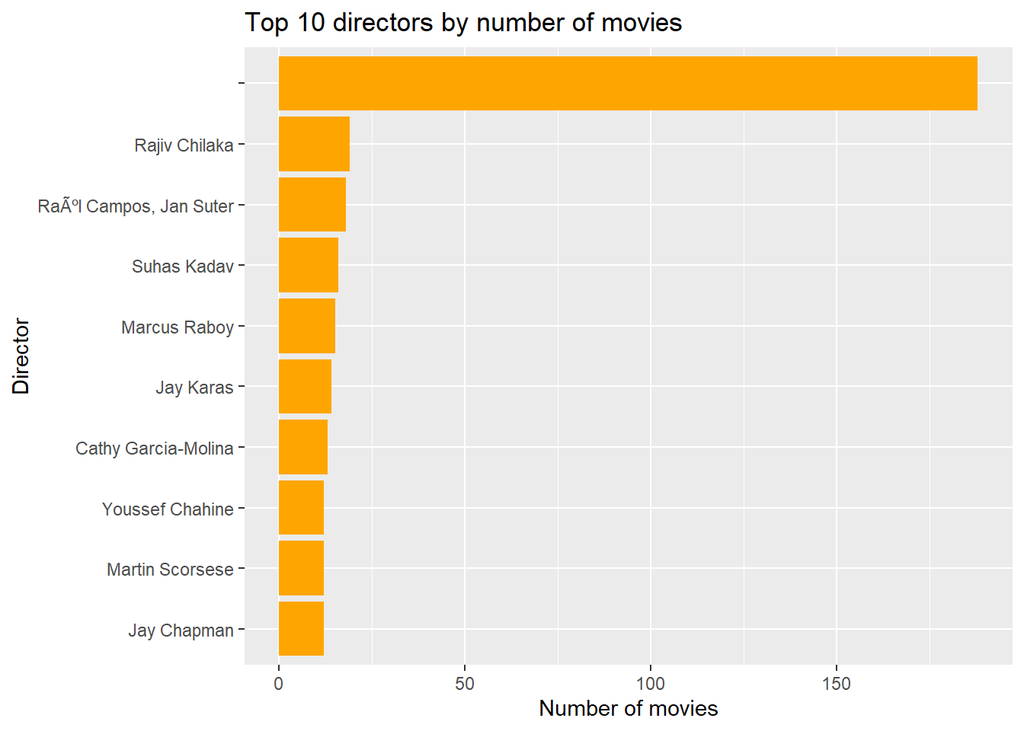

### Chart 2

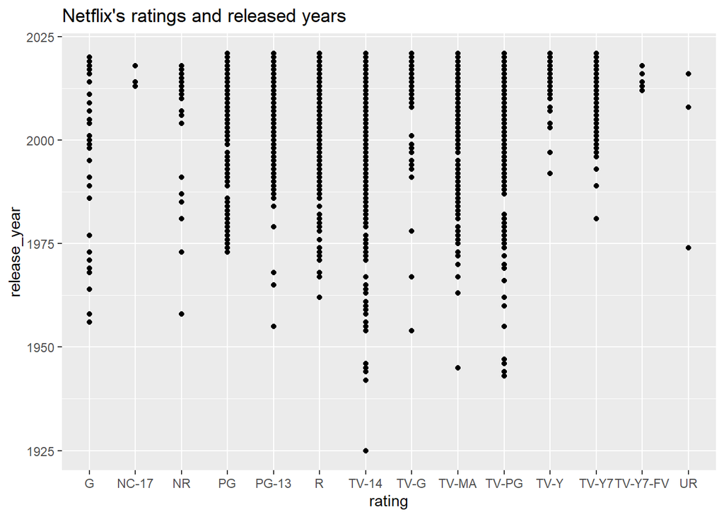

We chose this chart in order to see all the types of ratings that exists in Netflix’s streaming service and also compare it to the release year of that show or movie. This furthermore reveals a history of the industrial discourses surrounding Netflix’s audience data and concludes the discussion of streaming audience data that situates in the emerging’s realities of “popular” television in the context the medium’s broader transformation and continuities.

### Chart 3

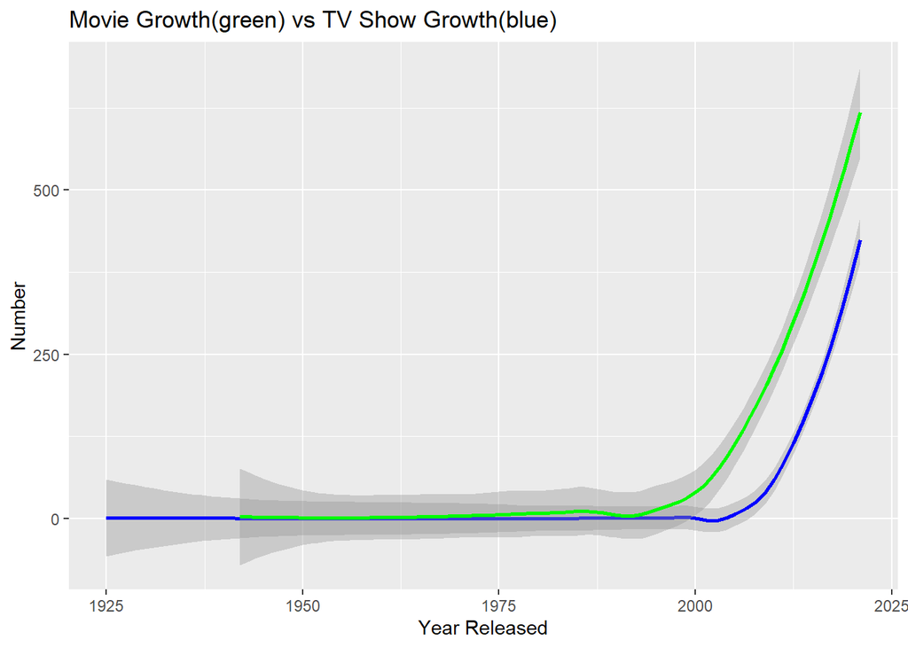